# Chapter 3: Understanding Data

# Understanding Data

Chapter Summary: This chapter introduces some basic concepts related to data. In particular, the chapter reviews data types, scales, descriptive statistics and data cleansing operations.

In order for us to mine data effectively, we will have to develop a clear understanding of the ideas motivating data-oriented approaches to problem solving. We will need to understand:

- The theories behind metadata, data types and measurement scale;
- The practical aspects of handling data including collecting descriptive statistics and data cleansing operations.

# Metadata, Data Types and Measurement Scales

## Metadata

Metadata is a description of the data in a data set. The `head()` function lets us review the first 6 rows of data in a data frame.

```r
algae_data <- read.csv("algae.csv")
head(algae_data)
```

```
##   season  size  speed mxPH mnO2     Cl    NO3     NH4    oPO4     PO4 Chla
## 1 winter small medium 8.00  9.8 60.800  6.238 578.000 105.000 170.000 50.0
## 2 spring small medium 8.35  8.0 57.750  1.288 370.000 428.750 558.750  1.3
## 3 autumn small medium 8.10 11.4 40.020  5.330 346.667 125.667 187.057 15.6
## 4 spring small medium 8.07  4.8 77.364  2.302  98.182  61.182 138.700  1.4
## 5 autumn small medium 8.06  9.0 55.350 10.416 233.700  58.222  97.580 10.5
## 6 winter small   high 8.25 13.1 65.750  9.248 430.000  18.250  56.667 28.4
##     a1   a2   a3  a4   a5   a6  a7
## 1  0.0  0.0  0.0 0.0 34.2  8.3 0.0
## 2  1.4  7.6  4.8 1.9  6.7  0.0 2.1
## 3  3.3 53.6  1.9 0.0  0.0  0.0 9.7
## 4  3.1 41.0 18.9 0.0  1.4  0.0 1.4
## 5  9.2  2.9  7.5 0.0  7.5  4.1 1.0
## 6 15.1 14.6  1.4 0.0 22.5 12.6 2.9
```

If we want to look at the metadata, however, we can use functions like `str()`.

```r
str(algae_data)
```

```
## 'data.frame':    200 obs. of  18 variables:
##  $ season: Factor w/ 4 levels "autumn","spring",..: 4 2 1 2 1 4 3 1 4 4 ...
##  $ size  : Factor w/ 3 levels "large","medium",..: 3 3 3 3 3 3 3 3 3 3 ...
##  $ speed : Factor w/ 3 levels "high","low","medium": 3 3 3 3 3 1 1 1 3 1 ...
##  $ mxPH  : num  8 8.35 8.1 8.07 8.06 8.25 8.15 8.05 8.7 7.93 ...
##  $ mnO2  : num  9.8 8 11.4 4.8 9 13.1 10.3 10.6 3.4 9.9 ...
##  $ Cl    : num  60.8 57.8 40 77.4 55.4 ...
##  $ NO3   : num  6.24 1.29 5.33 2.3 10.42 ...
##  $ NH4   : num  578 370 346.7 98.2 233.7 ...
##  $ oPO4  : num  105 428.8 125.7 61.2 58.2 ...
##  $ PO4   : num  170 558.8 187.1 138.7 97.6 ...
##  $ Chla  : num  50 1.3 15.6 1.4 10.5 ...
##  $ a1    : num  0 1.4 3.3 3.1 9.2 15.1 2.4 18.2 25.4 17 ...
##  $ a2    : num  0 7.6 53.6 41 2.9 14.6 1.2 1.6 5.4 0 ...
##  $ a3    : num  0 4.8 1.9 18.9 7.5 1.4 3.2 0 2.5 0 ...
##  $ a4    : num  0 1.9 0 0 0 0 3.9 0 0 2.9 ...
##  $ a5    : num  34.2 6.7 0 1.4 7.5 22.5 5.8 5.5 0 0 ...
##  $ a6    : num  8.3 0 0 0 4.1 12.6 6.8 8.7 0 0 ...
##  $ a7    : num  0 2.1 9.7 1.4 1 2.9 0 0 0 1.7 ...
```

The output from the `str()` function gives the description of each column in the data frame including:

- column name, example: “season”
- data type, example: “Factor w/ 4 levels”
- sample data, example: “4 2 1”

The `attributes()` function provide a different kind of summary of a data frame that includes:

- column names
- class (data type)
- row names

```r
attributes(algae_data)
```

```
## $names
##  [1] "season" "size"   "speed"  "mxPH"   "mnO2"   "Cl"     "NO3"
##  [8] "NH4"    "oPO4"   "PO4"    "Chla"   "a1"     "a2"     "a3"
## [15] "a4"     "a5"     "a6"     "a7"
##
## $class
## [1] "data.frame"
##
## $row.names
##   [1]   1   2   3   4   5   6   7   8   9  10  11  12  13  14  15  16  17
##  [18]  18  19  20  21  22  23  24  25  26  27  28  29  30  31  32  33  34
##  [35]  35  36  37  38  39  40  41  42  43  44  45  46  47  48  49  50  51
##  [52]  52  53  54  55  56  57  58  59  60  61  62  63  64  65  66  67  68
##  [69]  69  70  71  72  73  74  75  76  77  78  79  80  81  82  83  84  85
##  [86]  86  87  88  89  90  91  92  93  94  95  96  97  98  99 100 101 102
## [103] 103 104 105 106 107 108 109 110 111 112 113 114 115 116 117 118 119
## [120] 120 121 122 123 124 125 126 127 128 129 130 131 132 133 134 135 136
## [137] 137 138 139 140 141 142 143 144 145 146 147 148 149 150 151 152 153
## [154] 154 155 156 157 158 159 160 161 162 163 164 165 166 167 168 169 170
## [171] 171 172 173 174 175 176 177 178 179 180 181 182 183 184 185 186 187
## [188] 188 189 190 191 192 193 194 195 196 197 198 199 200
```

We can also retrieve the column names from a data frame with the `names()` function.

```r
names(algae_data)
```

```
##  [1] "season" "size"   "speed"  "mxPH"   "mnO2"   "Cl"     "NO3"
##  [8] "NH4"    "oPO4"   "PO4"    "Chla"   "a1"     "a2"     "a3"
## [15] "a4"     "a5"     "a6"     "a7"
```

Finally, we sometimes need to know the quantity of data in our data set.

`dim()` gives us the dimensions of our data frame.

`nrow()` gives us the number of rows.

`ncol()` gives us the number of columns.

```r
dim(algae_data)
```

```
## [1] 200  18
```

```r
nrow(algae_data)
```

```
## [1] 200
```

```r
ncol(algae_data)
```

```
## [1] 18
```

## Data Types

One of the most important pieces of metadata is the data type. The data type of a variable or a data frame column tells R what operations make sense on that data. For example, it probably doesn’t make much sense to try to multiply two names or dates. Data types provide structure to our data that helps analysts avoid doing crazy things.

R has many data types, but we will focus on the following:

`character` data types are appropriate for labels like ID fields.

`logical` types allow for two values: TRUE or FALSE.

`numeric` types are essentially decimals: 3.14

`integer` types represent numbers without decimal points.

`factor` types represent qualitative data in nominal or ordinal scales.

We need to know about data types because we will often need to convert our data from one type to another.

## Measurement Scales

Measurement scales help us to put our data into perspective by giving us a framework for understanding what we should and should not do with different kinds of measurements.

We track 4 different properties of measurement scales

http://stattrek.com/statistics/measurement-scales.aspx?Tutorial=AP

- Identity: each value in the scale has a unique meaning.
- Magnitude: the values in the scale can be ordered.
- Equal Intervals: the intervals between units are consistently scaled.
- A Minimum Value of Zero: The scale has a true zero point.

We can classify the measurement scale of our variables based on which properties they satisfy:

*nominal scale of meaurement*

In our current example, season is an example of variable at the nominal scale. Winter, Spring, Summer and Autumn function largely as labels. Although they are ordered in time, we wouldn’t say that they have magnitude exactly. In other words, winter isn’t more or less than spring in any meaningful way. The only property nominal variables satisfy is identity.

In practical terms, it only makes sense to count nominal values. For example, the only measure of central tendency that applies to variables at this scale is the mode. In R, variables at the nominal scale are generally stored with the factor data type.

*ordinal scale of measurement*

In our example, size and speed are examples of variables at the ordinal scale. Large rivers are larger than medium rivers and medium rivers are larger than small rivers. Measurements at this scale satisfy the identity and magnitude properties.

In practical terms, we can reliably use the mode and median for measures of central tendency at this scale. In R, variables at the ordinal scale are generally stored as ordered factors.

*interval scale of measurement*

A good example of a measurement at interval scale is temperature measured in degrees Celsius or Fahrenheit. These measurements satisfy the identity, magnitude and equal interval properties. The difference between 1 and 2 degrees Celsius is the same as the difference between 101 and 102 degrees Celsius.

In practical terms, we can reliably use the mode, median or arithmetic mean for measures of central tendency at this scale. In R, interval scale variables can be stored as integers or numeric types.

*ratio scale of measurement*

Weight is a good example of a ratio scale measurement. In addition to the properties of identity, magnitude, and equal interval, weight also has a meaningul minimum value of zero. Where the zeros in Fahrenheit and Celsius are arbitrary, a weight of zero is a true minimum that has meaning in the scale.

In practical terms, we can reliably use any measure of central tendency at this scale. In R, ratio scale variables are usually stored as numeric types.

Data types and measurement scales help us use our data responsibly. They help us understand what to do and not to do with different types of variables in our data frames.

# Descriptive Modeling

Successful data mining requires an in-depth understanding of the variables in a data set. Most projects, therefore, regardless of their ultimate goal requires descriptive modeling to support analysis and data cleansing. The rest of this chapter demonstrates the basics of descriptive modeling.

## How do we describe variables in our data set?

For data at the interval or ratio scale, we describe variables with four qualities: size, location, spread and shape.

The fastest way to gauge these qualities for a data frame is to use the `summary()` function.

```r
summary(algae_data)
```

```
##     season       size       speed         mxPH            mnO2
##  autumn:40   large :45   high  :84   Min.   :5.600   Min.   : 1.500
##  spring:53   medium:84   low   :33   1st Qu.:7.700   1st Qu.: 7.725
##  summer:45   small :71   medium:83   Median :8.060   Median : 9.800
##  winter:62                           Mean   :8.012   Mean   : 9.118
##                                      3rd Qu.:8.400   3rd Qu.:10.800
##                                      Max.   :9.700   Max.   :13.400
##                                      NA's   :1       NA's   :2
##        Cl               NO3              NH4                oPO4
##  Min.   :  0.222   Min.   : 0.050   Min.   :    5.00   Min.   :  1.00
##  1st Qu.: 10.981   1st Qu.: 1.296   1st Qu.:   38.33   1st Qu.: 15.70
##  Median : 32.730   Median : 2.675   Median :  103.17   Median : 40.15
##  Mean   : 43.636   Mean   : 3.282   Mean   :  501.30   Mean   : 73.59
##  3rd Qu.: 57.824   3rd Qu.: 4.446   3rd Qu.:  226.95   3rd Qu.: 99.33
##  Max.   :391.500   Max.   :45.650   Max.   :24064.00   Max.   :564.60
##  NA's   :10        NA's   :2        NA's   :2          NA's   :2
##       PO4              Chla               a1              a2
##  Min.   :  1.00   Min.   :  0.200   Min.   : 0.00   Min.   : 0.000
##  1st Qu.: 41.38   1st Qu.:  2.000   1st Qu.: 1.50   1st Qu.: 0.000
##  Median :103.29   Median :  5.475   Median : 6.95   Median : 3.000
##  Mean   :137.88   Mean   : 13.971   Mean   :16.92   Mean   : 7.458
##  3rd Qu.:213.75   3rd Qu.: 18.308   3rd Qu.:24.80   3rd Qu.:11.375
##  Max.   :771.60   Max.   :110.456   Max.   :89.80   Max.   :72.600
##  NA's   :2        NA's   :12
##        a3               a4               a5               a6
##  Min.   : 0.000   Min.   : 0.000   Min.   : 0.000   Min.   : 0.000
##  1st Qu.: 0.000   1st Qu.: 0.000   1st Qu.: 0.000   1st Qu.: 0.000
##  Median : 1.550   Median : 0.000   Median : 1.900   Median : 0.000
##  Mean   : 4.309   Mean   : 1.992   Mean   : 5.064   Mean   : 5.964
##  3rd Qu.: 4.925   3rd Qu.: 2.400   3rd Qu.: 7.500   3rd Qu.: 6.925
##  Max.   :42.800   Max.   :44.600   Max.   :44.400   Max.   :77.600
##
##        a7
##  Min.   : 0.000
##  1st Qu.: 0.000
##  Median : 1.000
##  Mean   : 2.495
##  3rd Qu.: 2.400
##  Max.   :31.600
##
```

If we compare the summary statistics for the different columns in our data, we see that nominal and ordinal variables report the mode, while interval and ratio scale variables report a battery of descriptive statistics including the min, first quartile, median, mean, third quartile and max.

We can also use our eyes by plotting either the histogram or the density function of our interval/ratio data. Let’s try this for maximum PH.

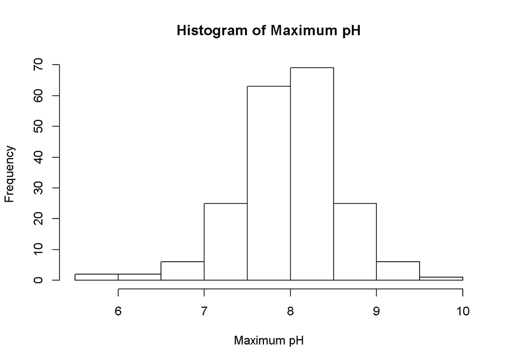

Histogram of maximum pH

```r
hist(algae_data$mxPH, xlab="Maximum pH", main="Histogram of Maximum pH")
```

Here is the histogram and density plot for a7:

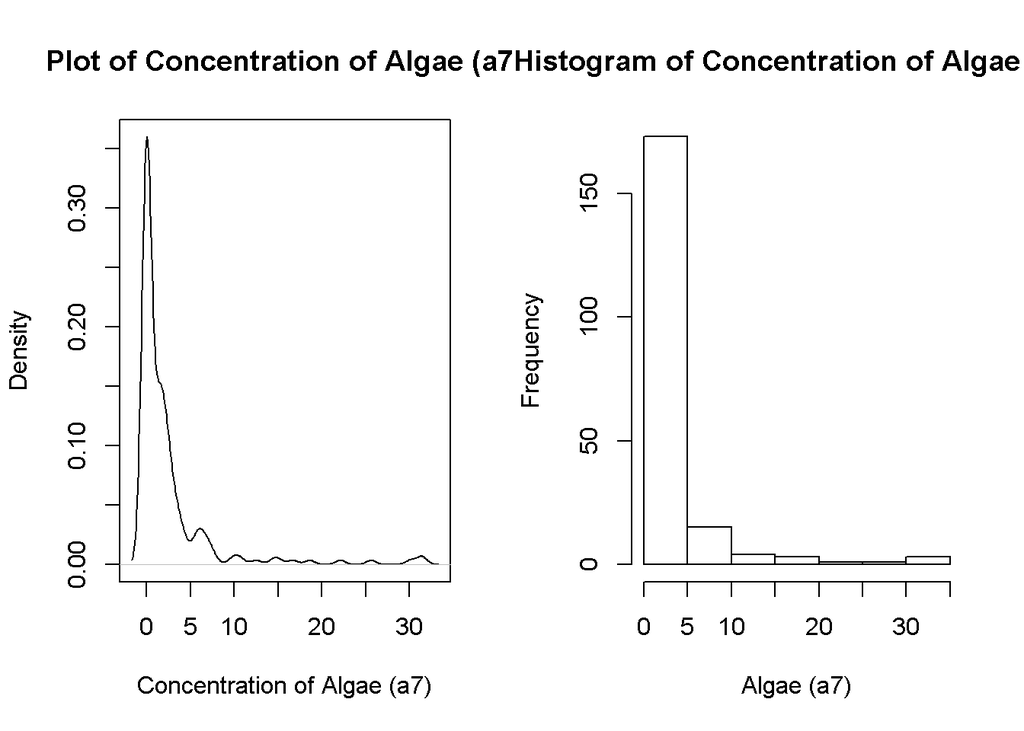

Shape of Algae (a7)

```r
par(mfrow=c(1,2))
plot(density(algae_data$a7), xlab="Concentration of Algae (a7)",
   main="Plot of Concentration of Algae (a7)")
hist(algae_data$a7, xlab="Algae (a7)", main="Histogram of Concentration of Algae (a7)")
```

```r
par(mfrow=c(1,1))
```

When we compare these two histograms, we learn a lot about the size, location, spread and shape of the distributions of these variables.

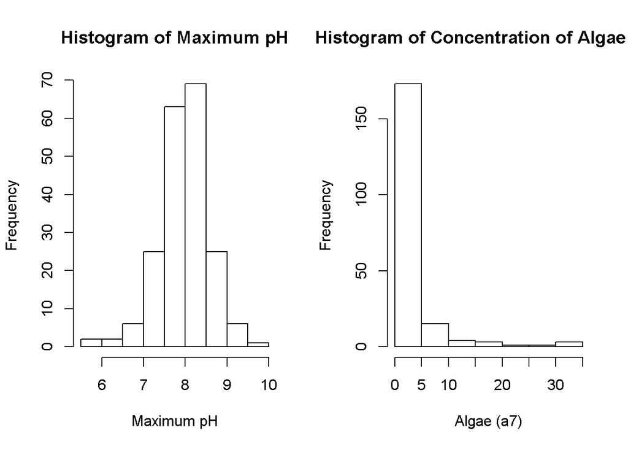

Histograms of Maximum pH and Algae (a7)

```r
par(mfrow=c(1,2))
hist(algae_data$mxPH, xlab="Maximum pH", main="Histogram of Maximum pH")
hist(algae_data$a7, xlab="Algae (a7)", main="Histogram of Concentration of Algae (a7)")
```

```r
par(mfrow=c(1,1))
```

## Size: How many observations do we have?

Characterizing the size of a variable is easy. We can use `length()` to determine the size of a specific variable.

```r
length(algae_data$mxPH)
```

```
## [1] 200
```

We can use `nrow()` or `dim()` to determine the number of observations in a data frame.

```r
nrow(algae_data)
```

```
## [1] 200
```

```r
dim(algae_data)
```

```
## [1] 200  18
```

We need to know the size of our data sets so that we can put our results into perspective. In the world of data mining generally, more observations is better because it increases our statistical power.

## Location: what does the typical value look like?

It is often useful to know what the typical value looks like. We often report measures of central tendency for this purpose: mode, median, mean. When we need a numerical summary of the typical value, we can use any of the standard measurements (where appropriate).

Let’s take measures of central tendency for algae a7.

```r
mean(algae_data$a7)
```

```
## [1] 2.4955
```

```r
median(algae_data$a7)
```

```
## [1] 1
```

```r
table(algae_data$a7)
```

```
##
##    0    1  1.1  1.2  1.4  1.5  1.6  1.7  1.9    2  2.1  2.2  2.3  2.4  2.5
##   98    8    1    5    9    2    3    4    7    1    3    4    1    5    1
##  2.7  2.9  3.2  3.3  3.4  3.6  3.9  4.1  4.2  4.3  4.9  5.2  5.5  5.8  5.9
##    4    3    3    2    1    1    3    1    1    1    1    1    1    1    1
##    6  6.1  6.6  6.8    7  7.1  7.2  7.8  9.7 10.2 10.8 12.5 14.4 15.1 16.7
##    2    2    1    1    1    1    1    1    1    1    1    1    1    1    1
## 18.6 22.1 25.6 30.1 31.2 31.6
##    1    1    1    1    1    1
```

## Spread: what do the atypical values look like?

We often need to know the spread of the data to get a sense of the atypical values in our data set. We report measures like the range, variance, standard deviation, and interquartile range. R provides functions for each of these measurements.

```r
range(algae_data$a7)
```

```
## [1]  0.0 31.6
```

```r
var(algae_data$a7)
```

```
## [1] 26.61078
```

```r
sd(algae_data$a7)
```

```
## [1] 5.158564
```

```r
IQR(algae_data$a7)
```

```
## [1] 2.4
```

## Shape: does the shape of the distribution tell us something?

R can produce metrics that capture the shape of a distribution: kurtosis and skewness. For the purposes of this class, however, we can address the shape by examining the histogram or density plot of a variable.

You should learn to recognize the following shapes in a variable:

*normal distribution*: the bell curve

The normal distribution has important mathematical properties that make data mining easier. We want to know if our data conforms roughly to this distribution.

Informally, normal distributions are symmetric in shape. They have medians and means that are very close together and roughly 2/3 of the data points should fall with 1 standard deviation of the mean.

Many variables in biology conform closely to the properties of a normal distributon.

*bimodal distribution*

Sometimes, we’ll see distributions with two bumps. This can indicate that we have two different underlying populations in our data.

*power law distribution*: long-tail distribution

In some cases, we see see variables that have really long tails in one direction. We want to note these variables because, depending on the severity of the skew, we may decide to adjust our strategy for handling these variables.

# Data Cleansing

We need to perform data cleansing to ensure that our variables can be used as we wish. For example, let’s try to take the arithmetic mean of maximum PH:

```r
mean(algae_data$mxPH)
```

```
## [1] NA
```

Why are we getting NA instead of a number?

Let’s review the summary information.

```r
summary(algae_data$mxPH)
```

```
##    Min. 1st Qu.  Median    Mean 3rd Qu.    Max.    NA's
##   5.600   7.700   8.060   8.012   8.400   9.700       1
```

We have a *missing value* for that variable in one of our observations. Let’s find it.

```r
algae_data[is.na(algae_data$mxPH),]
```

```
##    season  size speed mxPH mnO2 Cl  NO3 NH4 oPO4 PO4 Chla   a1 a2 a3 a4 a5
## 48 winter small   low   NA 12.6  9 0.23  10    5   6  1.1 35.5  0  0  0  0
##    a6 a7
## 48  0  0
```

For now, let’s just remove this row to make our lives easier.

```r
ad <- algae_data[!is.na(algae_data$mxPH),]
```

Now let’s try our arithmetic mean:

```r
mean(ad$mxPH)
```

```
## [1] 8.011734
```

We’ve just seen an example of how to remove missing values.

We will need to do many things like this when we cleanse our data. Here is a preview of the kinds of things you should be comfortable doing as we progress through the class.

## Identifying and Handling Missing Values

As we have seen, we can find columns with missing values (NAs) using the `summary()` function.

The `complete.cases()` function lets us do something similar for rows. The following function will give us a list of incomplete cases marked with the logical value TRUE.

```r
!complete.cases(algae_data)
```

```
##   [1] FALSE FALSE FALSE FALSE FALSE FALSE FALSE FALSE FALSE FALSE FALSE
##  [12] FALSE FALSE FALSE FALSE FALSE FALSE FALSE FALSE FALSE FALSE FALSE
##  [23] FALSE FALSE FALSE FALSE FALSE  TRUE FALSE FALSE FALSE FALSE FALSE
##  [34] FALSE FALSE FALSE FALSE  TRUE FALSE FALSE FALSE FALSE FALSE FALSE
##  [45] FALSE FALSE FALSE  TRUE FALSE FALSE FALSE FALSE FALSE FALSE  TRUE
##  [56]  TRUE  TRUE  TRUE  TRUE  TRUE  TRUE  TRUE  TRUE FALSE FALSE FALSE
##  [67] FALSE FALSE FALSE FALSE FALSE FALSE FALSE FALSE FALSE FALSE FALSE
##  [78] FALSE FALSE FALSE FALSE FALSE FALSE FALSE FALSE FALSE FALSE FALSE
##  [89] FALSE FALSE FALSE FALSE FALSE FALSE FALSE FALSE FALSE FALSE FALSE
## [100] FALSE FALSE FALSE FALSE FALSE FALSE FALSE FALSE FALSE FALSE FALSE
## [111] FALSE FALSE FALSE FALSE FALSE  TRUE FALSE FALSE FALSE FALSE FALSE
## [122] FALSE FALSE FALSE FALSE FALSE FALSE FALSE FALSE FALSE FALSE FALSE
## [133] FALSE FALSE FALSE FALSE FALSE FALSE FALSE FALSE FALSE FALSE FALSE
## [144] FALSE FALSE FALSE FALSE FALSE FALSE FALSE FALSE FALSE FALSE FALSE
## [155] FALSE FALSE FALSE FALSE FALSE FALSE  TRUE FALSE FALSE FALSE FALSE
## [166] FALSE FALSE FALSE FALSE FALSE FALSE FALSE FALSE FALSE FALSE FALSE
## [177] FALSE FALSE FALSE FALSE FALSE FALSE FALSE  TRUE FALSE FALSE FALSE
## [188] FALSE FALSE FALSE FALSE FALSE FALSE FALSE FALSE FALSE FALSE FALSE
## [199]  TRUE FALSE
```

We can insepct these cases with the following code:

```r
algae_data[!complete.cases(algae_data),]
```

```
##     season   size  speed mxPH mnO2    Cl   NO3 NH4    oPO4     PO4  Chla
## 28  autumn  small   high 6.80 11.1 9.000 0.630  20   4.000      NA  2.70
## 38  spring  small   high 8.00   NA 1.450 0.810  10   2.500   3.000  0.30
## 48  winter  small    low   NA 12.6 9.000 0.230  10   5.000   6.000  1.10
## 55  winter  small   high 6.60 10.8    NA 3.245  10   1.000   6.500    NA
## 56  spring  small medium 5.60 11.8    NA 2.220   5   1.000   1.000    NA
## 57  autumn  small medium 5.70 10.8    NA 2.550  10   1.000   4.000    NA
## 58  spring  small   high 6.60  9.5    NA 1.320  20   1.000   6.000    NA
## 59  summer  small   high 6.60 10.8    NA 2.640  10   2.000  11.000    NA
## 60  autumn  small medium 6.60 11.3    NA 4.170  10   1.000   6.000    NA
## 61  spring  small medium 6.50 10.4    NA 5.970  10   2.000  14.000    NA
## 62  summer  small medium 6.40   NA    NA    NA  NA      NA  14.000    NA
## 63  autumn  small   high 7.83 11.7 4.083 1.328  18   3.333   6.667    NA
## 116 winter medium   high 9.70 10.8 0.222 0.406  10  22.444  10.111    NA
## 161 spring  large    low 9.00  5.8    NA 0.900 142 102.000 186.000 68.05
```

[output cut: 19 more lines]

This syntax probably looks strange, so lets dig into it. We can access any row or column in a data frame from referring to its row or column number.

For example, if we want to see the data in the first row and column of algae_data, we can type:

```r
algae_data[1,1]
```

```
## [1] winter
## Levels: autumn spring summer winter
```

If we want to see everything in the first row, we type:

```r
algae_data[1,]
```

```
##   season  size  speed mxPH mnO2   Cl   NO3 NH4 oPO4 PO4 Chla a1 a2 a3 a4
## 1 winter small medium    8  9.8 60.8 6.238 578  105 170   50  0  0  0  0
##     a5  a6 a7
## 1 34.2 8.3  0
```

If we want to see everything in the first column, we type:

```r
algae_data[,1]
```

```
##   [1] winter spring autumn spring autumn winter summer autumn winter winter
##  [11] spring summer winter summer winter autumn winter spring summer spring
##  [21] winter spring autumn winter spring summer winter autumn winter spring
##  [31] autumn winter summer autumn winter summer winter spring winter spring
##  [41] winter summer winter spring winter spring autumn winter spring autumn
##  [51] winter summer winter spring winter spring autumn spring summer autumn
##  [61] spring summer autumn spring summer winter spring summer winter spring
##  [71] summer autumn summer winter spring spring autumn winter spring winter
##  [81] spring autumn winter summer autumn winter summer winter summer winter
##  [91] spring summer winter spring summer autumn winter spring winter summer
## [101] winter spring winter summer autumn winter summer autumn winter summer
## [111] winter spring summer spring summer winter summer autumn spring summer
## [121] winter spring summer winter spring summer winter spring summer winter
## [131] spring summer winter spring autumn spring autumn winter summer winter
## [141] summer spring autumn winter spring autumn winter autumn winter spring
## [151] autumn summer autumn spring autumn spring summer spring autumn winter
## [161] spring spring summer autumn winter autumn spring autumn winter autumn
## [171] winter summer winter spring spring winter autumn spring summer spring
## [181] summer winter summer winter summer winter winter summer autumn spring
## [191] autumn winter spring autumn summer autumn spring autumn winter summer
## Levels: autumn spring summer winter
```

So the code below asks R to return the rows with cases that are NOT complete. In other words, this code will return any rows with 1 or more NAs.

```r
algae_data[!complete.cases(algae_data),]
```

```
##     season   size  speed mxPH mnO2    Cl   NO3 NH4    oPO4     PO4  Chla
## 28  autumn  small   high 6.80 11.1 9.000 0.630  20   4.000      NA  2.70
## 38  spring  small   high 8.00   NA 1.450 0.810  10   2.500   3.000  0.30
## 48  winter  small    low   NA 12.6 9.000 0.230  10   5.000   6.000  1.10
## 55  winter  small   high 6.60 10.8    NA 3.245  10   1.000   6.500    NA
## 56  spring  small medium 5.60 11.8    NA 2.220   5   1.000   1.000    NA
## 57  autumn  small medium 5.70 10.8    NA 2.550  10   1.000   4.000    NA
## 58  spring  small   high 6.60  9.5    NA 1.320  20   1.000   6.000    NA
## 59  summer  small   high 6.60 10.8    NA 2.640  10   2.000  11.000    NA
## 60  autumn  small medium 6.60 11.3    NA 4.170  10   1.000   6.000    NA
## 61  spring  small medium 6.50 10.4    NA 5.970  10   2.000  14.000    NA
## 62  summer  small medium 6.40   NA    NA    NA  NA      NA  14.000    NA
## 63  autumn  small   high 7.83 11.7 4.083 1.328  18   3.333   6.667    NA
## 116 winter medium   high 9.70 10.8 0.222 0.406  10  22.444  10.111    NA
## 161 spring  large    low 9.00  5.8    NA 0.900 142 102.000 186.000 68.05
```

[output cut: 19 more lines]

If we decide to completely remove these observations, we could write code like this:

```r
ad <- algae_data[complete.cases(algae_data),]
```

`is.na()` can be used in a similar way within the scope of a single variable.

## Identifying and Removing Outliers

An easy visual way to identify outliers in your data is the box and whisker plot.

http://flowingdata.com/2008/02/15/how-to-read-and-use-a-box-and-whisker-plot/

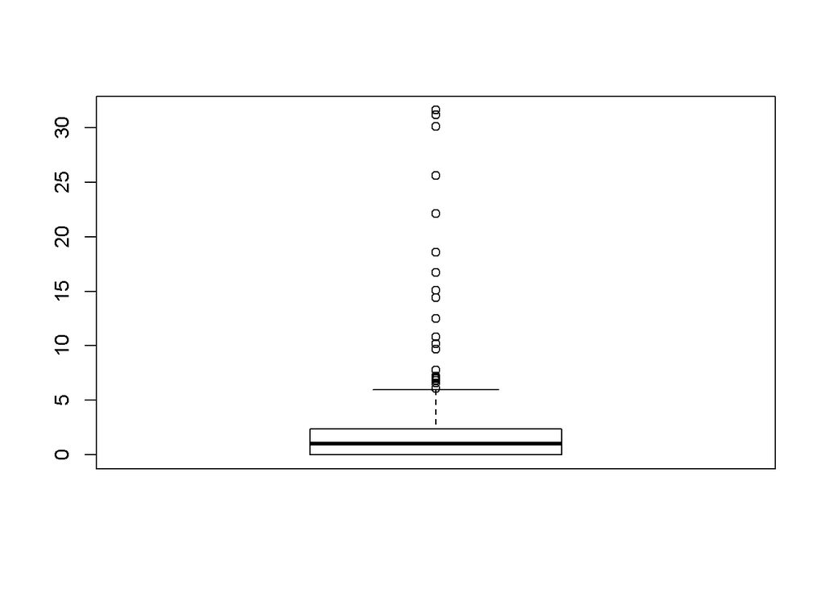

Boxplot of Algae a7

```r
boxplot(algae_data$a7)
```

The thick black line in the center of the box represents the median. 50% of the observations are higher (or lower) than this value.

The top of the box represents the upper quartile meaning that 25% of the observations are higher than this value.

The bottom of the box represents the lower quartile meaning that 25% of the observations are lower than this value.

The top whisker represents the max, excluding outliers. The dots above top whisker are outliers beyond Tukey’s upper inner fence.

The bottom whisker represents the min, excluding outliers. The dots below the bottom whisker are outliers beyond Tukey’s lower inner fence.

*Tukey Fences*

Let’s express the median, upper and lower quartiles with numbers.

```r
uq <- quantile(algae_data$a7,3/4)
m <- median(algae_data$a7)
lq <- quantile(algae_data$a7,1/4)
```

Now we can construct our Tukey fences.

```r
iqr <- IQR(algae_data$a7)
uof <- uq + (iqr * 3)
uif <- uq + (iqr * 1.5)
lif <- lif <- max(0,(lq - (iqr * 1.5)))
lof <- max(0,(lq - (iqr * 3)))
```

We can now filter by any of the fences. Let’s find all points outside of the upper inner Tukey fence. This should be the same set of points marked above the whisker.

```r
algae_data[algae_data$a7>uif,]
```

```
##     season   size  speed mxPH  mnO2     Cl   NO3      NH4    oPO4     PO4
## 3   autumn  small medium 8.10 11.40 40.020 5.330  346.667 125.667 187.057
## 18  spring  small   high 7.61  9.80  7.000 1.443   31.333  20.000  57.833
## 39  winter  small medium 8.30  8.90 20.625 3.414  228.750 196.620 253.250
## 41  winter  small medium 8.00  5.50 77.000 6.096  122.850 143.710 296.000
## 69  winter  small medium 7.50  1.50 32.400 0.921 1386.250 220.750 351.600
## 71  summer  small medium 7.80  7.10 32.540 1.720 2167.370 151.125 279.066
## 80  winter medium   high 7.50  9.20 11.000 3.310  101.000  26.600 108.000
## 82  autumn medium   high 7.30 11.70 10.400 4.930  130.000  10.800  60.000
## 83  winter medium   high 7.40  8.90 13.500 5.442  123.333  27.667 104.000
## 84  summer medium   high 7.40 11.17 12.146 6.188   89.600  32.000  69.930
## 85  autumn medium medium 7.50 10.80 31.000 4.408  737.500 111.250 214.000
## 86  winter medium medium 7.60  6.00 53.000 3.734  914.000 137.600 254.600
## 87  summer medium medium 7.40 10.77 36.248 3.730  429.200  57.600 169.001
## 96  autumn medium    low 8.50 10.50 56.717 0.330  215.714  23.000 138.500
```

[output cut: 29 more lines]

```r
uif
```

```
## 75%
##   6
```

*mean and standard deviation*

The mean and standard deviation used together can be a powerful way to detect outliers especially when we have a symmetric distribution like a normal curve.

The standard deviation is expressed in the same terms as the mean. This makes it an effective and meaningful basis for finding outliers.

Let’s pull out the missing values from maximum PH and look for outliers.

```r
ad <- algae_data[!is.na(algae_data$mxPH),]
```

Now let’s look for outliers.

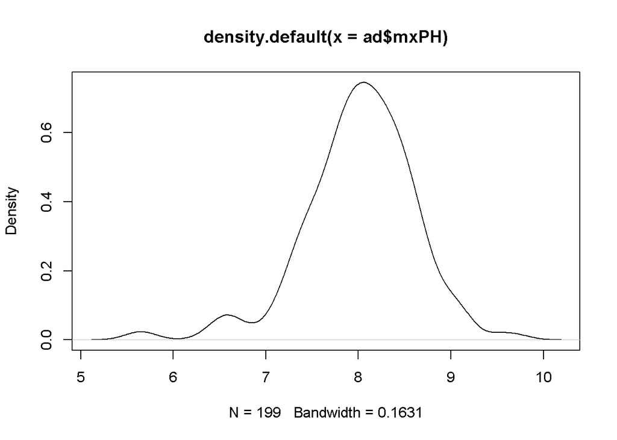

```r
plot(density(ad$mxPH))
```

We need to calculate the mean and standard deviation.

```r
am <- mean(ad$mxPH)
asd <- sd(ad$mxPH)
am
```

```
## [1] 8.011734
```

```r
median(ad$mxPH)
```

```
## [1] 8.06
```

```r
asd
```

```
## [1] 0.5983054
```

Let’s filter for records 2 standard deviations below the mean.

```r
lb <- am - (asd * 2)
lb
```

```
## [1] 6.815123
```

Then we can print out the outliers.

```r
ad[ad$mxPH<lb,]
```

```
##    season  size  speed mxPH mnO2 Cl   NO3 NH4 oPO4  PO4 Chla   a1  a2  a3
## 28 autumn small   high  6.8 11.1  9 0.630  20    4   NA  2.7 30.3 1.9 0.0
## 55 winter small   high  6.6 10.8 NA 3.245  10    1  6.5   NA 24.3 0.0 0.0
## 56 spring small medium  5.6 11.8 NA 2.220   5    1  1.0   NA 82.7 0.0 0.0
## 57 autumn small medium  5.7 10.8 NA 2.550  10    1  4.0   NA 16.8 4.6 3.9
## 58 spring small   high  6.6  9.5 NA 1.320  20    1  6.0   NA 46.8 0.0 0.0
## 59 summer small   high  6.6 10.8 NA 2.640  10    2 11.0   NA 46.9 0.0 0.0
## 60 autumn small medium  6.6 11.3 NA 4.170  10    1  6.0   NA 47.1 0.0 0.0
## 61 spring small medium  6.5 10.4 NA 5.970  10    2 14.0   NA 66.9 0.0 0.0
## 62 summer small medium  6.4   NA NA    NA  NA   NA 14.0   NA 19.4 0.0 0.0
##      a4  a5  a6  a7
## 28  0.0 2.1 1.4 2.1
## 55  0.0 0.0 0.0 0.0
## 56  0.0 0.0 0.0 0.0
## 57 11.5 0.0 0.0 0.0
## 58 28.8 0.0 0.0 0.0
## 59 13.4 0.0 0.0 0.0
## 60  0.0 0.0 1.2 0.0
## 61  0.0 0.0 0.0 0.0
## 62  2.0 0.0 3.9 1.7
```

# Summary

In this chapter, we reviewed some important concepts in data analysis like the difference between data and metadata, data types, and measurement scales. We also discussed some practical things that we can do with descriptive statistics like find and remove outliers from data.